# HutanDesa_Vegetation

Gene Estrada

2023-10-27

### Exploration

Starting with the 2016 vegetation data, which covers four Hutan Desas: Nipah Kuning, Padu Banjar, Pamangkat, and Pulau Kumbang.

```r
#it looks like all stems except 34 were ID'd to the species level
table(is.na(v$Species))
```

```
##
## FALSE  TRUE
##   764    34
```

```r
#only one stem did not have an ID to the genus level
table(is.na(v$Genus))
```

```
##
## FALSE  TRUE
##   797     1
```

The 2021 surveys cover the same HD sites as above, plus Penjalaan and Rantau Panjang

```r
#all but 46 stems were ID'd to the species level
table(is.na(v21$species))
```

```
##
## FALSE  TRUE
##  2178    46
```

```r
#all were ID'd to the genus level
table(is.na(v21$genus))
```

```
##
## FALSE
##  2224
```

### Vegetation Diversity

#### 2016 data -

Table showing counts of plant species by Hutan Desa

```r
species_table <- v %>%
  group_by(Location, scientific.name) %>%
  filter(!is.na(scientific.name)) %>%
  summarise(count = n()) %>%
  pivot_wider(names_from = Location, values_from = count, values_fill = 0) %>%
  arrange(desc(`Nipah Kuning`))
print(species_table, n = nrow(species_table))
```

```
## # A tibble: 87 × 5
##    scientific.name        `Nipah Kuning` `Padu Banjar` Pemangkat `Pulau Kumbang`
##    <chr>                           <int>         <int>     <int>           <int>
##  1 Lithocarpus leptogyne              32             0         0              28
##  2 Macaranga depressa                 29             9         1               0
##  3 Litsea lancifolia                  21            31        24              20
##  4 Stemonurus secundiflo…             21            19         7              11
##  5 Palaquium rostratum                20             9         1               6
##  6 Lithocarpus conocarpus             15             1         6               3
##  7 Blumeodendron tokbrai              12             0         3               1
##  8 Gonystylus bancanus                12             1         6               1
##  9 Nephelium maingayi                 10             9         1               3
## 10 Syzygium chloranthum               10            17         0               3
## 11 Xanthophyllum amoenum               9             2         0              10
## 12 Xylopia fusca                       8             0         0               0
```

[output cut: 75 more lines]

Table showing counts of plant genera by Hutan Desa

```r
genus_table <- v %>%
  group_by(Location, Genus) %>%
  filter(!is.na(Genus)) %>%
  summarise(count = n()) %>%
  pivot_wider(names_from = Location, values_from = count, values_fill = 0) %>%
  arrange(desc(`Nipah Kuning`))
print(genus_table, n = nrow(genus_table))
```

```
## # A tibble: 70 × 5
##    Genus             `Nipah Kuning` `Padu Banjar` Pemangkat `Pulau Kumbang`
##    <chr>                      <int>         <int>     <int>           <int>
##  1 Lithocarpus                   47             1         6              31
##  2 Macaranga                     29            13         1               0
##  3 Palaquium                     24            16         2               7
##  4 Syzygium                      23            23         2               7
##  5 Litsea                        22            37        24              20
##  6 Stemonurus                    21            19         7              11
##  7 Xanthophyllum                 13             2         0              13
##  8 Blumeodendron                 12             0         3               1
##  9 Gonystylus                    12             1         6               1
## 10 Nephelium                     10             9         1               3
## 11 Diospyros                      9            12         5               5
## 12 Ficus                          9             0         0               1
```

[output cut: 58 more lines]

Comparing plant species composition and diversity by Hutan Desa

```r
# Calculate species richness by site
species_richness <- v %>%
  group_by(Location) %>%
  summarise(SpeciesRichness = length(unique(scientific.name))) %>%
  arrange(desc(SpeciesRichness))

# Calculate Shannon diversity index by site
shannon_index <- diversity(table(v$Location, v$scientific.name), index = "shannon")
shannon_index <- rownames_to_column(as.data.frame(shannon_index), var = "Location")

# Calculate Simpson diversity index by site
simpson_index <- diversity(table(v$Location, v$scientific.name), index = "simpson")
simpson_index <- rownames_to_column(as.data.frame(simpson_index), var = "Location")

#create summary table
veg_summary <- merge(species_richness, shannon_index, by = "Location")
veg_summary <- merge(veg_summary, simpson_index, by = "Location")
veg_summary
```

```
##        Location SpeciesRichness shannon_index simpson_index
## 1  Nipah Kuning              60      3.521907     0.9570840
## 2   Padu Banjar              63      3.560305     0.9534437
## 3     Pemangkat              29      2.777344     0.8935740
## 4 Pulau Kumbang              28      2.711773     0.8956309
```

Comparing plant genus composition and diversity by Hutan Desa

```r
#by genus
genus_richness <- v %>%
  group_by(Location) %>%
  summarise(GenusRichness = n_distinct(Genus)) %>%
  arrange(desc(GenusRichness))

#Calculate Shannon diversity index by site
shannon_index_gen <- diversity(table(v$Location, v$Genus), index = "shannon")
shannon_index_gen <- rownames_to_column(as.data.frame(shannon_index_gen), var = "Location")

#Calculate Simpson diversity index by site
simpson_index_gen <- diversity(table(v$Location, v$Genus), index = "simpson")
simpson_index_gen <- rownames_to_column(as.data.frame(simpson_index_gen), var = "Location")

#create summary table
veg_summary_gen <- merge(genus_richness, shannon_index_gen, by = "Location")
veg_summary_gen <- merge(veg_summary_gen, simpson_index_gen, by = "Location")
veg_summary_gen
```

```
##        Location GenusRichness shannon_index_gen simpson_index_gen
## 1  Nipah Kuning            49          3.306967         0.9458639
## 2   Padu Banjar            52          3.289308         0.9400675
## 3     Pemangkat            28          2.801622         0.9004074
## 4 Pulau Kumbang            23          2.542487         0.8827160
```

#### 2021 data -

Table showing counts of plant species by Hutan Desa

```r
species_table_21 <- v21 %>%
  group_by(loc, scientific.name) %>%
  filter(!is.na(scientific.name)) %>%
  summarise(count = n()) %>%
  pivot_wider(names_from = loc, values_from = count, values_fill = 0) %>%
  arrange(desc(`Nipah Kuning`))
```

[output not shown]

```r
print(species_table_21, n = nrow(species_table_21))
```

```
## # A tibble: 109 × 7
##     scientific.name             `Nipah Kuning` `Padu Banjar` Pemangkat Penjalaan
##     <chr>                                <int>         <int>     <int>     <int>
##   1 Lithocarpus bancanus                    90             7        20         2
##   2 Litsea gracilipes                       65            38        67         9
##   3 Palaquium cochleariifolium              59             4         1         2
##   4 Stemonurus secundiflorus                52            25        20        16
##   5 Alseodaphne bancana                     34            42         5         5
##   6 Nephelium maingayi                      27            37         1        11
##   7 Ilex cymosa                             25             5         1         2
##   8 Diospyros siamang                       18             8         2         2
##   9 Madhuca motleyana                       17            29         2         6
##  10 Litsea angulata                         15             8         1        30
##  11 Xanthophyllum amoenum                   10             8         0         3
##  12 Horsfieldia crassifolia                  9             4         2         3
```

[output cut: 98 more lines]

Table showing counts of plant genera by Hutan Desa

```r
genus_table_21 <- v21 %>%
  group_by(loc, genus) %>%
  filter(!is.na(genus)) %>%
  summarise(count = n()) %>%
  pivot_wider(names_from = loc, values_from = count, values_fill = 0) %>%
  arrange(desc(`Nipah Kuning`))
```

[output not shown]

```r
print(genus_table_21, n = nrow(genus_table_21))
```

```
## # A tibble: 77 × 7
##    genus        `Nipah Kuning` `Padu Banjar` Pemangkat Penjalaan `Pulau Kumbang`
##    <chr>                 <int>         <int>     <int>     <int>           <int>
##  1 Lithocarpus              90             9        20         2              64
##  2 Litsea                   83            50        71        52              47
##  3 Palaquium                72            23         9        21               6
##  4 Stemonurus               58            26        20        20              12
##  5 Alseodaphne              34            42         5         5               3
##  6 Nephelium                27            37         1        11               0
##  7 Syzygium                 26            21        10        15               7
##  8 Ilex                     25             5         1         2               2
##  9 Diospyros                21             8         9         2               5
## 10 Xanthophyll…             18            31         7         8               7
## 11 Madhuca                  17            29         2         6               3
## 12 Blumeodendr…              9             8         6        10               4
```

[output cut: 66 more lines]

Comparing plant species composition and diversity by Hutan Desa

```r
# Calculate species richness by site
species_richness <- v21 %>%
  group_by(loc) %>%
  summarise(SpeciesRichness = length(unique(scientific.name))) %>%
  arrange(desc(SpeciesRichness))

# Calculate Shannon diversity index by site
shannon_index <- diversity(table(v21$loc, v21$scientific.name), index = "shannon")
shannon_index <- rownames_to_column(as.data.frame(shannon_index), var = "loc")

# Calculate Simpson diversity index by site
simpson_index <- diversity(table(v21$loc, v21$scientific.name), index = "simpson")
simpson_index <- rownames_to_column(as.data.frame(simpson_index), var = "loc")

#create summary table
veg_summary_21 <- merge(species_richness, shannon_index, by = "loc")
veg_summary_21 <- merge(veg_summary_21, simpson_index, by = "loc")
veg_summary_21
```

```
##              loc SpeciesRichness shannon_index simpson_index
## 1   Nipah Kuning              68      3.291662     0.9349664
## 2    Padu Banjar              62      3.547540     0.9595060
## 3      Pemangkat              40      2.800472     0.8690735
## 4      Penjalaan              66      3.677457     0.9625017
## 5  Pulau Kumbang              43      2.758274     0.8726378
## 6 Rantau Panjang              66      3.518082     0.9472089
```

Ordination analysis - ***still working on this

```r
#get data in right format - I think I need to not group by site here, and by survey/transect instead
t1 <- v %>%
  group_by(Location, scientific.name) %>%
  filter(!is.na(scientific.name)) %>%
  summarise(count = n()) %>%
  pivot_wider(names_from = scientific.name, values_from = count, values_fill = 0)
#run ordination
MDS1 <- metaMDS(t1[,-1], distance = "euclidean")
```

```
## Wisconsin double standardization
## *** Best solution was not repeated -- monoMDS stopping criteria:
##     20: stress < smin
```

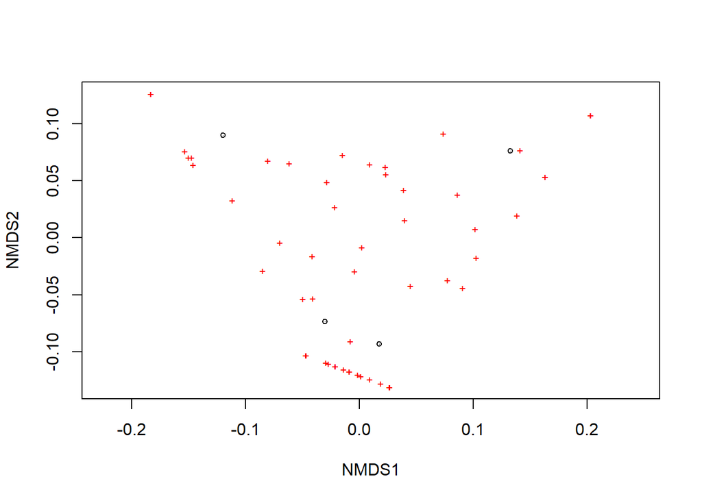

```r
#plot
plot(MDS1, type = "points")
ordihull(MDS1, groups = 1:4, col = "green", draw = "polygon")
```

#### Andy’s pheno data from CPRS

Creating list of species in pheno plots with counts. Note, pheno plots were not placed in the Montane (MO) forest, so there is no data here to compare for the montane.

Not many species are listed here. Looking at the data, it looks like not many stems were identified to the species level.

```r
species_table_CPRS <- pheno %>%
  filter(hab_unbiased == "PS" & pheno_year == "2016") %>%
  group_by(scientific.name) %>%
  filter(!is.na(scientific.name)) %>%
  summarise(count = n()) %>%
  arrange(desc(count))

print(species_table_CPRS, n = nrow(species_table_CPRS))
```

```
## # A tibble: 53 × 2
##    scientific.name               count
##    <chr>                         <int>
##  1 "Palaquium leiocarpum"          240
##  2 "Gonystylus bancanus"            84
##  3 "Stemonurus glob"                60
##  4 "Ficus urostigma"                48
##  5 "Madhuca kingiana"               36
##  6 "Palaquium microphyllum"         36
##  7 "Polyalthia sumatrana"           36
##  8 "Syzygium spnov"                 36
##  9 "Tetramerista glabra"            36
## 10 "Ficus brachtylena"              24
## 11 "Ficus stupenda"                 24
## 12 "Ficus xanthophylla"             24
```

[output cut: 41 more lines]

Doing the same thing again but for genus. Many more stems were identified to the genus level.

```r
genus_table_CPRS <- pheno %>%
  filter(hab_unbiased == "PS" & pheno_year == "2016") %>%
  group_by(genus) %>%
  filter(!is.na(genus)) %>%
  summarise(count = n()) %>%
  arrange(desc(count))

print(genus_table_CPRS, n = nrow(genus_table_CPRS))
```

```
## # A tibble: 119 × 2
##     genus           count
##     <chr>           <int>
##   1 Syzygium         1044
##   2 Combretum        1005
##   3 Palaquium         660
##   4 Stemonurus        589
##   5 Bauhinia          480
##   6 Garcinia          276
##   7 Macaranga         264
##   8 Polyalthia        264
##   9 Xanthophyllum     252
##  10 Memecylon         240
##  11 Shorea            240
##  12 Ficus             236
```

[output cut: 107 more lines]

Calculating plant species diversity indices by forest type at CPRS

```r
# Calculate species richness by site
species_richness_CPRS <- pheno %>%
  group_by(hab_unbiased) %>%
  summarise(SpeciesRichness = n_distinct(scientific.name)) %>%
  arrange(desc(SpeciesRichness))

# Calculate Shannon diversity index by site
shannon_index_CPRS <- diversity(table(pheno$hab_unbiased, pheno$scientific.name), index = "shannon")
shannon_index_CPRS <- rownames_to_column(as.data.frame(shannon_index_CPRS), var = "hab_unbiased")

# Calculate Simpson diversity index by site
simpson_index_CPRS <- diversity(table(pheno$hab_unbiased, pheno$scientific.name), index = "simpson")
simpson_index_CPRS <- rownames_to_column(as.data.frame(simpson_index_CPRS), var = "hab_unbiased")

#create summary table
veg_summary_CPRS <- merge(species_richness_CPRS, shannon_index_CPRS, by = "hab_unbiased")
veg_summary_CPRS <- merge(veg_summary_CPRS, simpson_index_CPRS, by = "hab_unbiased")

veg_summary_CPRS %>%
  arrange(desc(hab_unbiased))
```

```
##   hab_unbiased SpeciesRichness shannon_index_CPRS simpson_index_CPRS
## 1           UG              27           2.750118          0.9023723
## 2           LG              56           3.394032          0.9446166
## 3           LS              87           3.822916          0.9514012
## 4           AB              65           3.558341          0.9448343
## 5           FS              68           3.850332          0.9706057
## 6           PS              55           3.466120          0.9380578
```

Calculating plant genus diversity indices by forest type at CPRS. It might make sense to use these indices for comparison to the Hutan Desa, at least from Andy’s data, given the lack of species ID’s, as seen above.

```r
# Calculate species richness by site
genus_richness_CPRS <- pheno %>%
  group_by(hab_unbiased) %>%
  summarise(GenusRichness = n_distinct(genus))

# Calculate Shannon diversity index by site
shannon_index_CPRS_gen <- diversity(table(pheno$hab_unbiased, pheno$genus), index = "shannon")
shannon_index_CPRS_gen <- rownames_to_column(as.data.frame(shannon_index_CPRS_gen), var = "hab_unbiased")

# Calculate Simpson diversity index by site
simpson_index_CPRS_gen <- diversity(table(pheno$hab_unbiased, pheno$genus), index = "simpson")
simpson_index_CPRS_gen <- rownames_to_column(as.data.frame(simpson_index_CPRS_gen), var = "hab_unbiased")

#create summary table
veg_summary_CPRS_gen <- merge(genus_richness_CPRS, shannon_index_CPRS_gen, by = "hab_unbiased")
veg_summary_CPRS_gen <- merge(veg_summary_CPRS_gen, simpson_index_CPRS_gen, by = "hab_unbiased")

veg_summary_CPRS_gen %>%
  arrange(desc(hab_unbiased))
```

```
##   hab_unbiased GenusRichness shannon_index_CPRS_gen simpson_index_CPRS_gen
## 1           UG           128               3.902478              0.9603479
## 2           LG           121               4.101974              0.9703432
## 3           LS           135               4.410447              0.9830714
## 4           AB           119               4.068804              0.9728979
## 5           FS           135               4.299299              0.9798512
## 6           PS           122               3.944532              0.9640695
```

Comparing plant species diversity between CPRS forests and HD sites. Again, if using Andy’s data moving forward in any way, comparing these values at the genus level might be best.

```r
#by species
colnames(veg_summary_CPRS) <- c("Location", "SpeciesRichness", "shannon_index", "simpson_index")
veg_summary_CPRS <- veg_summary_CPRS %>% arrange(Location)
rbind(veg_summary, veg_summary_CPRS)
```

```
##         Location SpeciesRichness shannon_index simpson_index
## 1   Nipah Kuning              60      3.521907     0.9570840
## 2    Padu Banjar              63      3.560305     0.9534437
## 3      Pemangkat              29      2.777344     0.8935740
## 4  Pulau Kumbang              28      2.711773     0.8956309
## 5             PS              55      3.466120     0.9380578
## 6             FS              68      3.850332     0.9706057
## 7             AB              65      3.558341     0.9448343
## 8             LS              87      3.822916     0.9514012
## 9             LG              56      3.394032     0.9446166
## 10            UG              27      2.750118     0.9023723
```

```r
#by genus
colnames(veg_summary_CPRS_gen) <- c("Location", "GenusRichness", "shannon_index_gen", "simpson_index_gen")
veg_summary_CPRS_gen <- veg_summary_CPRS_gen %>% arrange(Location)
rbind(veg_summary_gen, veg_summary_CPRS_gen)
```

```
##         Location GenusRichness shannon_index_gen simpson_index_gen
## 1   Nipah Kuning            49          3.306967         0.9458639
## 2    Padu Banjar            52          3.289308         0.9400675
## 3      Pemangkat            28          2.801622         0.9004074
## 4  Pulau Kumbang            23          2.542487         0.8827160
## 5             PS           122          3.944532         0.9640695
## 6             FS           135          4.299299         0.9798512
## 7             AB           119          4.068804         0.9728979
## 8             LS           135          4.410447         0.9830714
## 9             LG           121          4.101974         0.9703432
## 10            UG           128          3.902478         0.9603479
```

### Structural Comparison

Using structural metrics DBH and Tree height to compare Hutan Desa sites. There doesn’t seem to be much difference here. I’m not sure that I’ll be using these metrics moving forward, so just visually assessing for now.

#### 2016 data -

Tree DBH - one obvious outlier here in the Pemangkat site

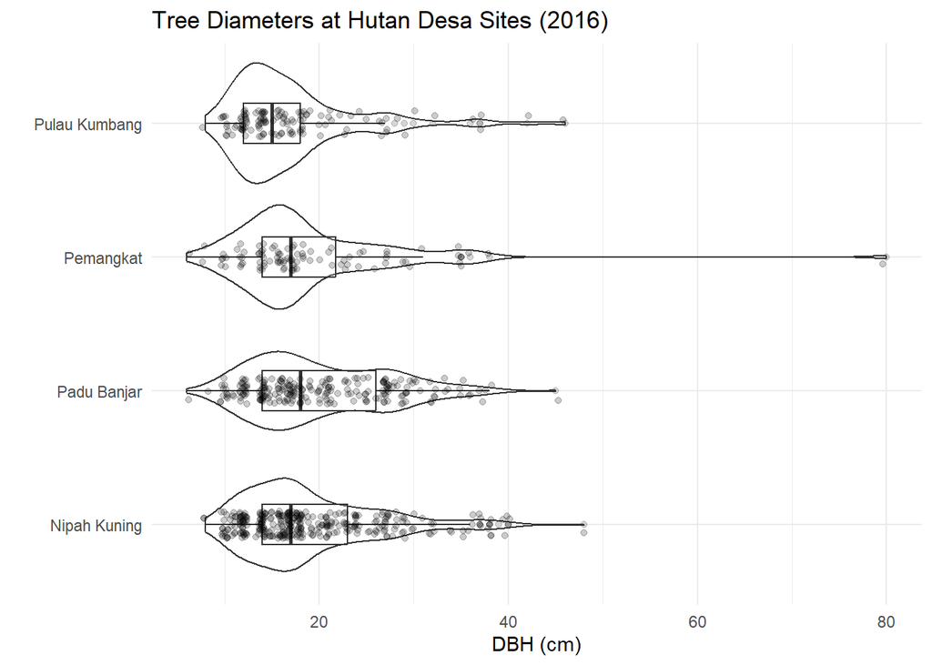

```r
ggplot(v, aes(x = DBH, y = Location)) +
  geom_violin() +
  geom_boxplot(width=0.3, alpha=0.2) +
  geom_jitter(height = .1, alpha = 0.2) +
  labs(title = "Tree Diameters at Hutan Desa Sites (2016)",
       x = "DBH (cm)", y = "") +
  theme_minimal()
```

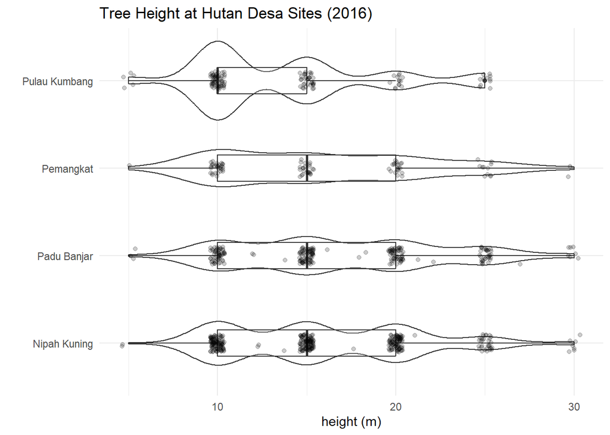

```r
ggplot(v, aes(x = Tree.Height, y = Location)) +
  geom_violin() +
  geom_boxplot(width=0.3, alpha=0.2) +
  geom_jitter(height = .1, alpha = 0.2) +
  labs(title = "Tree Height at Hutan Desa Sites (2016)",
       x = "height (m)", y = "") +
  theme_minimal()
```

#### 2021 data - only has DBH

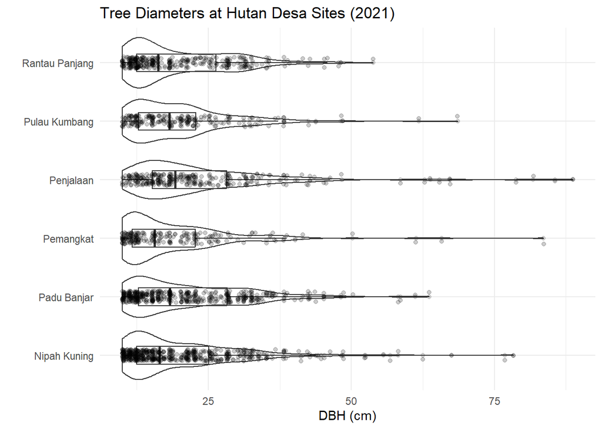

```r
ggplot(v21, aes(x = dbh, y = loc)) +
  geom_violin() +
  geom_boxplot(width=0.3, alpha=0.2) +
  geom_jitter(height = .1, alpha = 0.2) +
  labs(title = "Tree Diameters at Hutan Desa Sites (2021)",
       x = "DBH (cm)", y = "") +
  theme_minimal()
```